# **Laboratorio 7: Text Mining**

## **Integrantes:** Ian Berdichewsky y Cristóbal Mancilla. Sección 2

## Objetivo

Explorar el procesamiento de lenguaje natural (NLP).

## Instrucciones

1. Trabajen en equipos de dos personas. Salvo excepciones, no se corregirá entregas con menos de dos integrantes.
2. Quienes no asisten a la clase auxiliar entregan el laboratorio de manera individual.
3. Modifique este archivo `.ipynb` agregando sus respuestas donde corresponda. Puede utilizar la funciones de Python o construir sus propias funciones.
4. Para cada pregunta **incluya el código fuente que utilizó para llegar a su respuesta. Respuestas sin código no recibirán puntaje.**.
5. El formato de entrega para esta actividad es un archivo **html**. **Genere un archivo HTML usando Jupyter** y súbalo a U-Cursos. Basta con que un/a integrante haga la entrega. Si ambos/as hacen una entrega en U-Cursos, se revisará cualquiera de éstas.

**Para una mejor experiencia de aprendizaje, les recomendamos desactivar cualquier tipo de LLM (ChatGPT, Copilot, Claude, etc.) mientras realizan este laboratorio. Les recompensará en el futuro entender el código que escribieron y les permitirá aprender a programar de verdad para usar estos modelos de manera más efectiva. [Más información](https://www.scotthyoung.com/blog/2023/04/25/chatgpt-learning-obsolete/#:~:text=As%20mentioned%20in%20the%20research,two%20people%20on%20their%20own.)**

El procesamiento de lenguaje natural permite transformar texto libre en representaciones numéricas para entrenar modelos de aprendizaje automático.

En este laboratorio usaremos un enfoque clásico de **text mining** para **sentiment analysis**: primero tokenizaremos reviews, luego construiremos una representación **Bag of Words** y finalmente entrenaremos clasificadores que predigan si una review es positiva o negativa.

```python
import re
from collections import Counter
from pathlib import Path

import numpy as np
import pandas as pd

import matplotlib.pyplot as plt

from sklearn.feature_extraction.text import CountVectorizer
from sklearn.linear_model import LogisticRegression
from sklearn.metrics import accuracy_score, classification_report, confusion_matrix, ConfusionMatrixDisplay
from sklearn.model_selection import train_test_split
from sklearn.naive_bayes import MultinomialNB
```

## Dataset

Nuestro dataset contiene reviews etiquetadas por sentimiento:

- `TrainingDataNegative.txt`: reviews negativas.
- `TrainingDataPositive.txt`: reviews positivas.
- `TestReviews.csv`: reviews de prueba, cuando está disponible.

La celda siguiente carga el dataset desde Kaggle. Si el dataset no está disponible en el ambiente de ejecución, el notebook debe fallar para que el problema sea visible y se instale/configure la dependencia correspondiente.

```python
def read_review_lines(path):
    text = path.read_text(encoding="utf-8", errors="ignore")
    lines = [line.strip() for line in text.splitlines() if line.strip()]
    return lines

import kagglehub
from pathlib import Path

dataset = "ahmedabdulhamid/reviews-dataset"
dataset_path = Path(kagglehub.dataset_download(dataset))

positive_path = dataset_path / "TrainingDataPositive.txt"
negative_path = dataset_path / "TrainingDataNegative.txt"
test_path = dataset_path / "TestReviews.csv"

### Conjunto de entrenamiento
positive_reviews = read_review_lines(positive_path)
negative_reviews = read_review_lines(negative_path)

print("Dataset descargado en:", dataset_path)

positive_txt = "\n".join(positive_reviews)
negative_txt = "\n".join(negative_reviews)

reviews_df_train = pd.DataFrame({
    "text": positive_reviews + negative_reviews,
    "label": [1] * len(positive_reviews) + [0] * len(negative_reviews),
})

reviews_df_train = reviews_df_train.sample(frac=1, random_state=42).reset_index(drop=True)

print("Cantidad de reviews:", len(reviews_df_train))
print("Distribución de clases:")
display(reviews_df_train["label"].value_counts().rename(index={1: "positiva", 0: "negativa"}))
display(reviews_df_train.head())

# Conjunto de prueba
test_df = pd.read_csv(test_path).rename(columns={"review": "text", "class": "label"})
```

```
Using Colab cache for faster access to the 'reviews-dataset' dataset.
Dataset descargado en: /kaggle/input/reviews-dataset
Cantidad de reviews: 11210
Distribución de clases:
```

| label | count |
| --- | --- |
| positiva | 7961 |
| negativa | 3249 |

**dtype:** int64

|  | text | label |
| --- | --- | --- |
| 0 | THANK YOU ROB! i truly appreciated all the hel... | 1 |
| 1 | Just walked in for a tapas sampler and a drink... | 1 |
| 2 | Our group of 15 needed a place for dinner afte... | 1 |
| 3 | The sandwiches, the wings, enough said. Alexio... | 1 |
| 4 | It was the first time I've ever been here and ... | 1 |

```python
## Muestra del conjunto de prueba
test_df.head()
```

|  | text | label |
| --- | --- | --- |
| 0 | Fantastic spot for an even or a quite cocktail... | 1 |
| 1 | Love, love, love the calamari. It's so good an... | 1 |
| 2 | Love this place. Stiff martinis and cocktails,... | 1 |
| 3 | It's everything a great cocktail bar should be... | 1 |
| 4 | I came here before a pirates game, so it was a... | 1 |

# **Parte 1:**

## Pregunta 1: Tokenización

Definiremos una función **`get_tokens()`** que reciba un texto y entregue una lista con sus tokens.

```python
def get_tokens(texto):
    # Busca secuencias alfanuméricas completas.
    patron = r"\b\w+\b"
    tokens = re.findall(patron, texto)
    return tokens
```

```python
positive_tokens = get_tokens(positive_txt)
negative_tokens = get_tokens(negative_txt)

print("Tokens positivos:", positive_tokens[:10])
print("Tokens negativos:", negative_tokens[:10])
```

```
Tokens positivos: ['This', 'paddle', 'sport', 'supply', 'store', 'is', 'stocked', 'to', 'the', 'rafters']
Tokens negativos: ['Perhaps', 'good', 'product', 'but', 'really', 'poor', 'service', 'My', 'wife', 'and']
```

1. Explique el razonamiento detrás del tokenizador. ¿Qué significa la expresión regular `r"\b\w+\b"`?
2. ¿Qué problemas puede tener este tokenizador al trabajar con reviews reales?
3. ¿Qué otras reglas se podrían añadir para sentiment analysis?

**Respuesta**:

1. Es lo que separa las palabras de un texto. La regex `r"\b\w+\b"` funciona así: `\w` es un "carácter de palabra" (letras, números y guion bajo), `+` significa "uno o más seguidos", y los `\b` marcan los bordes de la palabra (donde empieza y termina). Entonces busca secuencias de letras/números y deja afuera los espacios y signos de puntuación.
2. Toma las mayúsculas y minúsculas como palabras distintas. No cuenta caracteres como los signos de exclamación, que pueden dar más intensidad. Y lo más grave para sentiment analysis es que, por ejemplo "don't" lo separa en "don" y "t", así que se pierde la negación.
3. Se podría añadir un filtro que pase todo a minúsculas, que tome en cuenta caracteres como signos de expresión, emojis o guiones, y que expanda las contracciones ("don't" -> "do not") para no perder los "not".

## Pregunta 2: Preprocesamiento, stemming y stopwords

Las **stopwords** son palabras frecuentes que suelen aportar poca información semántica. En sentiment analysis hay que tener cuidado: palabras como `not`, `no` o `never` pueden cambiar completamente la polaridad de una review, por lo que no las eliminaremos.

Implementaremos:

- `normalize_text()`: normaliza texto y elimina caracteres no alfabéticos.
- `pre_processing()`: elimina stopwords y aplica stemming simple.
- `tokenizer()`: combina tokenización y preprocesamiento.

```python
STOPWORDS = {
    "a", "an", "the", "and", "or", "but", "if", "to", "of", "in", "on", "for",
    "with", "as", "by", "at", "from", "this", "that", "these", "those", "it",
    "is", "are", "was", "were", "be", "been", "being", "i", "you", "he", "she",
    "we", "they", "my", "your", "our", "their", "me", "him", "her", "them",
}


def normalize_text(text):
    text = text.lower()
    text = re.sub(r"[^a-z\s]", " ", text)
    text = re.sub(r"\s+", " ", text).strip()
    return text


def simple_stem(word):
    substitutions = [
        ("sses", "ss"),
        ("ies", "i"),
        ("ing", ""),
        ("ed", ""),
        ("ly", ""),
        ("s", ""),
    ]
    for old, new in substitutions:
        if word.endswith(old) and len(word) > len(old) + 2:
            return word[:-len(old)] + new
    return word


def pre_processing(vocabulario):
    processed = []
    for token in vocabulario:
        token = token.lower()
        if token in STOPWORDS:
            continue
        processed.append(simple_stem(token))
    return processed


def tokenizer(text):
    normalized = normalize_text(text)
    tokens = get_tokens(normalized)
    return pre_processing(tokens)

## Aplicar tokenizador al conjunto train
reviews_df_train["tokens"] = reviews_df_train["text"].apply(tokenizer)
display(reviews_df_train[["text", "tokens", "label"]].head())

## Aplicar tokenizador al conjunto test
test_df["tokens"] = test_df["text"].apply(tokenizer)
```

|  | text | tokens | label |
| --- | --- | --- | --- |
| 0 | THANK YOU ROB! i truly appreciated all the hel... | [thank, rob, tru, appreciat, all, help, receiv... | 1 |
| 1 | Just walked in for a tapas sampler and a drink... | [just, walk, tapa, sampler, drink, sampler, ex... | 1 |
| 2 | Our group of 15 needed a place for dinner afte... | [group, need, place, dinner, after, sister, s,... | 1 |
| 3 | The sandwiches, the wings, enough said. Alexio... | [sandwiche, wing, enough, said, alexion, can, ... | 1 |
| 4 | It was the first time I've ever been here and ... | [first, time, ve, ever, here, lov, meal, quite... | 1 |

```python
## Muestra del resultado de tokenización aplicado al conjunto de test
display(test_df[["text", "tokens", "label"]].head())
```

|  | text | tokens | label |
| --- | --- | --- | --- |
| 0 | Fantastic spot for an even or a quite cocktail... | [fantastic, spot, even, quite, cocktail, swell... | 1 |
| 1 | Love, love, love the calamari. It's so good an... | [love, love, love, calamari, s, so, good, spic... | 1 |
| 2 | Love this place. Stiff martinis and cocktails,... | [love, place, stiff, martini, cocktail, cheap,... | 1 |
| 3 | It's everything a great cocktail bar should be... | [s, everyth, great, cocktail, bar, should, gre... | 1 |
| 4 | I came here before a pirates game, so it was a... | [came, here, before, pirate, game, so, around,... | 1 |

1. ¿Por qué puede ayudar eliminar stopwords antes de entrenar un clasificador?
2. ¿Por qué no conviene eliminar palabras como `not`, `no` o `never` en sentiment analysis?

**Respuesta**:

1. Porque esas palabras generan ruido y no ayudan realmente al sentiment analysis, pues no añaden información valiosa como normalmente son palabras como conectores.
2. Porque son palabras que diferencian entre positivo y negativo, pues si no se tomaran en cuenta, frases como "I never eat vegetables" se guardarían como "I eat vegetables" y es lo opuesto a lo que se refería el texto original.

## Pregunta 3: Bag of Words

La representación **Bag of Words** transforma cada documento en un vector de frecuencias. Cada columna representa una palabra del vocabulario y cada fila representa una review.

Primero implementaremos una versión manual para entender la representación. Luego usaremos `CountVectorizer`, que es la herramienta habitual para entrenar modelos con `scikit-learn`.

```python
def build_vocabulary(tokenized_docs, min_df=1, max_features=None):
    document_frequency = Counter()
    for tokens in tokenized_docs:
        document_frequency.update(set(tokens))

    terms = [term for term, df in document_frequency.items() if df >= min_df]
    terms = sorted(terms, key=lambda term: (-document_frequency[term], term))

    if max_features is not None:
        terms = terms[:max_features]

    return terms


def bag_of_words(tokenized_docs, vocabulary):
    rows = []
    for tokens in tokenized_docs:
        counts = Counter(tokens)
        rows.append({term: counts.get(term, 0) for term in vocabulary})
    return pd.DataFrame(rows, columns=vocabulary)


manual_vocab = build_vocabulary(reviews_df_train["tokens"], min_df=1, max_features=25)
manual_bow = bag_of_words(reviews_df_train["tokens"], manual_vocab)
manual_bow["label"] = reviews_df_train["label"].values

manual_bow_test = bag_of_words(test_df["tokens"], manual_vocab) #solo transforma, manual_vocab no sabe nada de test set, así evista el data leakage

print("Tamaño del vocabulario manual:", len(manual_vocab))
display(manual_bow.head())
```

```
Tamaño del vocabulario manual: 25
```

|  | have | place | t | food | not | s | so | had | there | great | ... | one | just | very | get | go | can | service | when | back | label |
| --- | --- | --- | --- | --- | --- | --- | --- | --- | --- | --- | --- | --- | --- | --- | --- | --- | --- | --- | --- | --- | --- |
| 0 | 0 | 0 | 1 | 0 | 0 | 0 | 0 | 1 | 0 | 1 | ... | 0 | 0 | 0 | 0 | 0 | 1 | 1 | 1 | 0 | 1 |
| 1 | 0 | 0 | 0 | 0 | 0 | 0 | 0 | 0 | 0 | 0 | ... | 0 | 1 | 0 | 0 | 0 | 0 | 0 | 0 | 0 | 1 |
| 2 | 2 | 1 | 4 | 2 | 1 | 2 | 0 | 1 | 0 | 3 | ... | 3 | 2 | 1 | 1 | 0 | 2 | 0 | 0 | 2 | 1 |
| 3 | 1 | 0 | 2 | 0 | 2 | 1 | 0 | 3 | 0 | 0 | ... | 0 | 0 | 0 | 0 | 1 | 2 | 0 | 1 | 1 | 1 |
| 4 | 2 | 1 | 4 | 3 | 2 | 0 | 3 | 4 | 1 | 2 | ... | 0 | 0 | 0 | 0 | 0 | 0 | 1 | 1 | 1 | 1 |

5 rows × 26 columns

```python
cv = CountVectorizer(
    tokenizer=tokenizer,
    preprocessor=None,
    token_pattern=None,
    lowercase=False,
    min_df=2,
)

X_train = cv.fit_transform(reviews_df_train["text"])  ## fit + transform en train
labels_train = reviews_df_train["label"].values
feature_names = np.array(cv.get_feature_names_out())

X_test = cv.transform(test_df["text"])               # solo transform en test

print("Matriz BoW:", X_train.shape)
print("Matriz BoW test: ", X_test.shape)
print("Primeras 20 features:")
print(feature_names[:20])
```

```
Matriz BoW: (11210, 13558)
Matriz BoW test:  (4321, 13558)
Primeras 20 features:
['aa' 'aaa' 'aabc' 'aaron' 'aback' 'abalone' 'abandon' 'abay' 'abc' 'abd'
 'abe' 'abercrombie' 'abide' 'abiliti' 'ability' 'able' 'abode'
 'abomination' 'aboslute' 'abou']
```

```python
bow_df = pd.DataFrame(
    X_train.toarray(),
    columns=feature_names,
)
bow_df["label"] = labels_train
display(bow_df.head())
```

|  | aa | aaa | aabc | aaron | aback | abalone | abandon | abay | abc | abd | ... | zip | zombi | zombie | zone | zonie | zoo | zucchini | zumba | zuppa | zur |
| --- | --- | --- | --- | --- | --- | --- | --- | --- | --- | --- | --- | --- | --- | --- | --- | --- | --- | --- | --- | --- | --- |
| 0 | 0 | 0 | 0 | 0 | 0 | 0 | 0 | 0 | 0 | 0 | ... | 0 | 0 | 0 | 0 | 0 | 0 | 0 | 0 | 0 | 0 |
| 1 | 0 | 0 | 0 | 0 | 0 | 0 | 0 | 0 | 0 | 0 | ... | 0 | 0 | 0 | 0 | 0 | 0 | 0 | 0 | 0 | 0 |
| 2 | 0 | 0 | 0 | 0 | 0 | 0 | 0 | 0 | 0 | 0 | ... | 0 | 0 | 0 | 0 | 0 | 0 | 0 | 0 | 0 | 0 |
| 3 | 0 | 0 | 0 | 0 | 0 | 0 | 0 | 0 | 0 | 0 | ... | 0 | 0 | 0 | 0 | 0 | 0 | 0 | 0 | 0 | 0 |
| 4 | 0 | 0 | 0 | 0 | 0 | 0 | 0 | 0 | 0 | 0 | ... | 0 | 0 | 0 | 0 | 0 | 0 | 0 | 0 | 0 | 0 |

5 rows × 13558 columns

1. ¿Qué representa cada fila y cada columna de la matriz Bag of Words?
2. ¿Qué significa que `features.shape` sea `(n_reviews, n_palabras)`?
3. ¿Qué información se pierde al usar Bag of Words?

**Respuesta**:

1. Cada fila representa una review y cada columna representa una palabra del vocabulario, y cada intersección es la frecuencia de sta.
2. N_reviews es la cantidad de reviews que se usaron y n_palabras representa la cantidad de palabras, entonces features.shape representa las dimensiones de la matriz.
3. Como la bag of words solamente toma las palabras textuales, no revisa el contexto de estas y el orden en la cual se escribieron.

## Pregunta 4: Clasificadores de sentimientos

Entrenaremos dos clasificadores:

1. **Multinomial Naive Bayes**, un modelo clásico para conteos de palabras.
2. **Logistic Regression**, un clasificador lineal que suele funcionar bien con Bag of Words.

Evaluaremos ambos con accuracy, precision, recall, F1-score y demás métricas obtenidas en la matriz de confusión.

```python
## Train y test ya están separados desde el origen de los datos, por tanto
## ... a continuación ajustaremos los modelos de aprendizaje automático

models = {
    "Multinomial Naive Bayes": MultinomialNB(),
    "Logistic Regression": LogisticRegression(max_iter=1000, random_state=42),
}

results = []
predictions = {}

for name, model in models.items():
    model.fit(X_train, labels_train)
    y_pred = model.predict(X_test)
    predictions[name] = y_pred
    results.append({
        "modelo": name,
        "accuracy": accuracy_score(test_df["label"], y_pred),
    })

results_df = pd.DataFrame(results).sort_values("accuracy", ascending=False)
display(results_df)
```

|  | modelo | accuracy |
| --- | --- | --- |
| 1 | Logistic Regression | 0.947929 |
| 0 | Multinomial Naive Bayes | 0.932192 |

```
================================================================================
Multinomial Naive Bayes
              precision    recall  f1-score   support

    negativa       0.88      0.90      0.89      1332
    positiva       0.96      0.94      0.95      2989

    accuracy                           0.93      4321
   macro avg       0.92      0.92      0.92      4321
weighted avg       0.93      0.93      0.93      4321
```

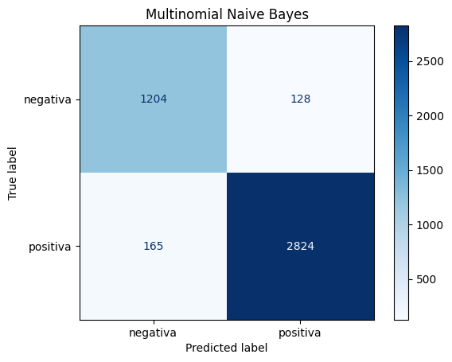

```
================================================================================
Logistic Regression
              precision    recall  f1-score   support

    negativa       0.93      0.90      0.91      1332
    positiva       0.95      0.97      0.96      2989

    accuracy                           0.95      4321
   macro avg       0.94      0.93      0.94      4321
weighted avg       0.95      0.95      0.95      4321
```

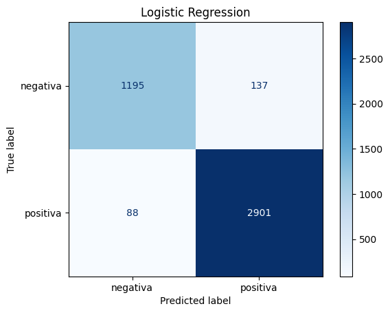

```python
for name, y_pred in predictions.items():
    print("=" * 80)
    print(name)
    print(classification_report(
        test_df["label"].values,
        y_pred,
        target_names=["negativa", "positiva"],
        zero_division=0,
    ))

    cm = confusion_matrix(test_df["label"].values, y_pred)
    if plt is not None:
        disp = ConfusionMatrixDisplay(cm, display_labels=["negativa", "positiva"])
        disp.plot(cmap="Blues")
        plt.title(name)
        plt.show()
    else:
        display(pd.DataFrame(
            cm,
            index=["real_negativa", "real_positiva"],
            columns=["pred_negativa", "pred_positiva"],
        ))
```

```python
# Vamos a extraer las palabras más influyentes para cada modelo según los pesos.
## Este código devuelve dos tablas para cada modelo, una en la que se muestran las 10 palabras que ...
## ... influyen más en la predicción del sentimiento positivo y la otra con respecto al sentimiento negativo

def show_top_words(model, feature_names, n=10):
    if hasattr(model, "coef_"):
        weights = model.coef_[0]
        top_positive = pd.DataFrame({
            "palabra": feature_names[np.argsort(weights)[-n:][::-1]],
            "peso": np.sort(weights)[-n:][::-1],
        })
        top_negative = pd.DataFrame({
            "palabra": feature_names[np.argsort(weights)[:n]],
            "peso": np.sort(weights)[:n],
        })
        return top_positive, top_negative

    if hasattr(model, "feature_log_prob_"):
        # Diferencia entre log-probabilidad positiva y negativa.
        weights = model.feature_log_prob_[1] - model.feature_log_prob_[0]
        top_positive = pd.DataFrame({
            "palabra": feature_names[np.argsort(weights)[-n:][::-1]],
            "peso": np.sort(weights)[-n:][::-1],
        })
        top_negative = pd.DataFrame({
            "palabra": feature_names[np.argsort(weights)[:n]],
            "peso": np.sort(weights)[:n],
        })
        return top_positive, top_negative

    raise ValueError("Modelo no soportado")


for name, model in models.items():
    top_pos, top_neg = show_top_words(model, feature_names, n=10)
    print("=" * 80)
    print(name)
    print("Palabras más asociadas a sentimiento positivo")
    display(top_pos)
    print("Palabras más asociadas a sentimiento negativo")
    display(top_neg)
```

```
================================================================================
Multinomial Naive Bayes
Palabras más asociadas a sentimiento positivo
```

|  | palabra | peso |
| --- | --- | --- |
| 0 | gem | 4.019295 |
| 1 | comic | 3.895426 |
| 2 | workout | 3.335810 |
| 3 | mmm | 3.191229 |
| 4 | impeccable | 3.191229 |
| 5 | terrific | 3.048128 |
| 6 | cardio | 3.048128 |
| 7 | informative | 3.022152 |
| 8 | superb | 2.981878 |
| 9 | frick | 2.981878 |

```
Palabras más asociadas a sentimiento negativo
```

|  | palabra | peso |
| --- | --- | --- |
| 0 | tasteles | -5.210554 |
| 1 | unacceptable | -4.198953 |
| 2 | rude | -4.186246 |
| 3 | unprofessional | -4.111941 |
| 4 | poison | -3.999824 |
| 5 | inedible | -3.814107 |
| 6 | acknowledg | -3.706476 |
| 7 | filthy | -3.683487 |
| 8 | vomit | -3.659956 |
| 9 | uncook | -3.659956 |

```
================================================================================
Logistic Regression
Palabras más asociadas a sentimiento positivo
```

|  | palabra | peso |
| --- | --- | --- |
| 0 | amaz | 2.607860 |
| 1 | excellent | 2.295582 |
| 2 | deliciou | 2.290817 |
| 3 | perfect | 2.038736 |
| 4 | love | 2.003444 |
| 5 | fantastic | 1.883482 |
| 6 | great | 1.829390 |
| 7 | best | 1.809370 |
| 8 | yummy | 1.762478 |
| 9 | favorite | 1.687463 |

```
Palabras más asociadas a sentimiento negativo
```

|  | palabra | peso |
| --- | --- | --- |
| 0 | horrible | -2.712217 |
| 1 | worst | -2.704284 |
| 2 | rude | -2.491518 |
| 3 | poor | -2.421194 |
| 4 | mediocre | -1.955066 |
| 5 | awful | -1.922970 |
| 6 | bland | -1.886351 |
| 7 | terrible | -1.795516 |
| 8 | disgust | -1.651130 |
| 9 | overpric | -1.466522 |

1. ¿Cuál de los dos clasificadores tuvo mejor desempeño? Justifique usando las métricas.
2. Observe las palabras con mayor peso. ¿Tienen sentido para sentiment analysis?

**Respuesta**:

1. El mejor clasificador fue Logistic Regression, pues si nos fijamos en las métricas supera a Naive Bayes en casi todas (solo pierde por 0.01 en la precisión positiva, y empatan en el recall negativo), así que es claramente mejor.
2. En general sí, son palabras con mucho peso sentimental ("fuertes", como excellent u horrible), que se usan en contextos muy ligados a emociones. Eso se ve clarito en Logistic Regression. En Naive Bayes igual aparecen palabras raras que en realidad no son positivas por sí solas (como comic, workout, cardio o mmm), que se cuelan porque son poco frecuentes pero aparecen casi siempre en reviews positivas del dataset.

# **Parte 2: Embeddings**

Los word embeddings son representaciones vectoriales densas (un vector de números reales con todos sus elementos significativos) de palabras.

Estas representaciones logran transferir la semántica hacia un espacio vectorial. Palabras semánticamente similares se encuentran cercanas en el espacio vectorial. A continuación, crearemos los embeddings del conjunto de datos `reviews_df_train` y `test_df`, con el fin de explorar, analizar y entrenar un modelo de clasificación que procesa embeddings.

```python
# Ejecute el siguiente código si desea explorar su funcionamiento. El tiempo de ejecución aproximadamente es de 25 minutos, por tanto,
## ...en las secciones en donde se use su resultado, se les mostrará lo requerido para analizar y responder la respectiva pregunta
### NOta: para ejecutarlo el código es necesario eliminar las comillas del inicio y final del bloque

"""

from sentence_transformers import SentenceTransformer
import pickle

# Modelo con el transformer
model = SentenceTransformer("all-MiniLM-L6-v2")

# Generar embeddings del train
textos = reviews_df_train['text'].tolist()

embeddings_train = model.encode(
    textos,
    batch_size=64,
    show_progress_bar=True,
    convert_to_numpy=True
)


## Generar embeddings del test
embeddings_test = model.encode(
    test_df["text"].tolist(),
    batch_size=64,
    show_progress_bar=True,
    convert_to_numpy=True,
)

## Ver el resultado de los embeddings
print(f"Shape train: {embeddings_train.shape}")
print(f"Shape test:  {embeddings_test.shape}")

# Guardar embeddings
np.save("embeddings_train.npy", embeddings_train)
np.save("embeddings_test.npy", embeddings_test)

with open("embeddings.pkl", "wb") as f:
    pickle.dump({
        "textos_train": reviews_df_train["text"].tolist(),
        "embeddings_train": embeddings_train,
        "labels_train": reviews_df_train["label"].tolist(),
        "textos_test": test_df["text"].tolist(),
        "embeddings_test": embeddings_test,
        "labels_test": test_df["label"].tolist(),
    }, f)

  """
```

```python
# Verificar que se guardaron los embeddings.
## Nota: Subir a "Files" los arhivos: "embeddings_train.npy", "embeddings_test.npy" y "embeddings.pkl"
import pickle

with open("embeddings.pkl", "rb") as f:
    data_embeddings = pickle.load(f)

print(f"Train: {len(data_embeddings['textos_train'])} reviews")
print(f"Test:  {len(data_embeddings['textos_test'])} reviews")
```

[output not shown]

```python
## a continuación cargaremos los embeddings a partir de os archivos "embeddings_train.npy" y "embeddings_test.npy"
### embeddings.pkl — contiene: textos, vectores y labels de train y test.
### embeddings_train.npy — solo los vectores de entrenamiento.
### embeddings_test.npy — solo los vectores de test.


embeddings_train = data_embeddings["embeddings_train"]
embeddings_test  = data_embeddings["embeddings_test"]
labels_train     = data_embeddings["labels_train"]

print(f"Shape train: {embeddings_train.shape}")
print(f"Shape test:  {embeddings_test.shape}")
```

[output not shown]

## Pregunta 5: Similitud entre embeddings

Con el siguiente código se muestran los primeros tres embeddings del conjunto de datos de reseñas de `embeddeings_train`.

```python
# Obtener los primeros tres embeddings con el respectivo texto de cada reseña.
## ## Nota: la ejecución del código es opcional


textos_train = data_embeddings["textos_train"]
embeddings_train = data_embeddings["embeddings_train"]

for i in range(3):
  print(f"Review {i+1}: {textos_train[i][:150]}...")
  print(f"Vector: [{','.join(f'{v:.4f}' for v in embeddings_train[i][:20])}...] (dim={len(embeddings_train[i])})")
  print()
```

[output not shown]

Con base en el resultado de la **Bag of Words (BOW)** obtenido en la pregunta 3 y en los embeddings, a continuación hallaremos la similitud entre los vectores obtenidos para las primeras tres reseñas a partir de BOW y sus respectivos embeddings. Responda a las siguientes preguntas:

- ¿Hay algún par de reseñas en donde BoW y embeddings den resultados muy distintos? Si es así, lean los pares de reseñas y expliquen por qué creen que difieren.
- ¿Cuál representación (BOW vs embeddings) creen que refleja mejor la similitud real entre las reseñas?

```python
from sklearn.metrics.pairwise import cosine_similarity
import numpy as np

# Primeras 3 reseñas
bow_3 = manual_bow.drop(columns=["label"]).iloc[:3].values
emb_3 = embeddings_train[:3]

# Similitud entre las reseñas utilizando cosine_similarity
sim_bow = cosine_similarity(bow_3)
sim_emb = cosine_similarity(emb_3)

# Tabla comparativa entre las reseñas
pares = [("Reseña 1 vs 2", 0, 1),
         ("Reseña 1 vs 3", 0, 2),
         ("Reseña 2 vs 3", 1, 2)]

print(f"{'Par':<20} {'BoW':>10} {'Embedding':>12}")
print("-" * 44)
for nombre, i, j in pares:
    print(f"{nombre:<20} {sim_bow[i,j]:>10.4f} {sim_emb[i,j]:>12.4f}")
```

[output not shown]

## Pregunta 6: Similitud entre palabras

Ahora elegiremos cuatro palabras ("good", "awesome", "terrifying", "bad"), en este caso solo nos enfocaremos en los vectores de palabras obtenidos de los embeddings.

```python
# Vector de una palabra "awesome"
## ## Nota: la ejecución del código es opcional

"""
vector = model.encode("awesome")

print(f"Dimensiones: {vector.shape}")   # Dimensión del vector de la palabra awesome
print(f"Primeros 5 valores: {vector[:5].round(4)}") # Ver los primeros cinco valores del vector de la palabra awesome
print(f"Min: {vector.min():.4f} | Max: {vector.max():.4f}") # Valores mínimo y máximo del vector de la palabra "awesome"
"""
```

**Resultado: vector de la palabra "awesome"**

```
# Dimensiones: (384,)
Primeros 5 valores: [-0.0729 -0.0866 -0.0705 -0.0602  0.079 ]
# Min: -0.1421 | Max: 0.1809
```

```python
# Ahora obtendremos los vectores de las cuatro palabras a partir de los embeddings y calcularemos la similitud coseno entre esos vectores
import numpy as np
from sentence_transformers import SentenceTransformer
model = SentenceTransformer("all-MiniLM-L6-v2")

palabras = ["good", "awesome", "terrifying", "bad"]
embeddings_4 = model.encode(palabras)

# Similaridad entre las palabras utilizando cosine_similarity
for i, palabra_a in enumerate(palabras):
    for j, palabra_b in enumerate(palabras):
        if j <= i:
            continue
        sim = cosine_similarity([embeddings_4[i]], [embeddings_4[j]])[0][0]
        print(f"'{palabra_a}' vs '{palabra_b}': {sim:.3f}")
```

[output not shown]

**Respuesta:**

- Pasa porque los embeddings agrupan las palabras según el contexto en que se usan, no según si son positivas o negativas. "Good" y "bad", aunque son opuestas, se usan en frases casi idénticas ("the food was good" / "the food was bad"), entonces aparecen rodeadas de las mismas palabras y les quedan vectores parecidos. En cambio "awesome" es más informal e intensa y se usa en otros contextos, por eso "awesome" vs "bad" da más bajo. O sea lo que mide la similitud es el "cómo se usan" las palabras, no el sentimiento.
- No es un error, tiene sentido y es algo normal de este tipo de embeddings. Igual eso no significa que sirvan mal para sentiment analysis: la info de si es positivo o negativo igual está guardada en el vector, solo que no se nota en la similitud coseno general. Por eso un modelo entrenado con estos embeddings (como el GaussianNB de la pregunta 7) igual puede separar lo positivo de lo negativo.

## Pregunta 7: Modelamiento con embeddings

Vamos a entrenar un modelo Bayesiano de aprendizaje automático, [GaussianNB](https://scikit-learn.org/stable/modules/generated/sklearn.naive_bayes.GaussianNB.html), que utiliza los embeddings para realizar las predicciones. En nuestro caso se predice sentimientos positivo o negativo hacia las reseñas del conjunto de datos pre-procesado en el modelo de embeddings.

Considerando los resultados del modelo, responda a las siguientes preguntas:

- ¿qué se puede concluir del desempeño de este modelo con respecto al mejor modelo identificado en la respuesta a la pregunta 4?
- ¿Qué cree que puede llevar a que el modelo GaussianNB haya tenido ese desempeño, considerando que al utilizar los embeddings camptura más semántica que BOW?

```python
from sklearn.naive_bayes import GaussianNB
from sklearn.metrics import accuracy_score, classification_report

GNB = GaussianNB()
GNB.fit(embeddings_train, labels_train)
```

```
GaussianNB()
```

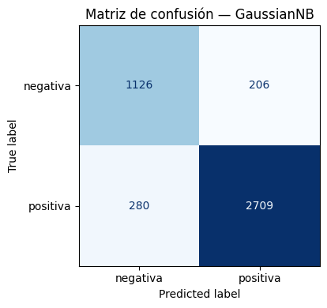

|  | precision | recall | f1-score | support |
| --- | --- | --- | --- | --- |
| negativa | 0.8009 | 0.8453 | 0.8225 | 1332.0000 |
| positiva | 0.9293 | 0.9063 | 0.9177 | 2989.0000 |
| accuracy | 0.8875 | 0.8875 | 0.8875 | 0.8875 |
| macro avg | 0.8651 | 0.8758 | 0.8701 | 4321.0000 |
| weighted avg | 0.8897 | 0.8875 | 0.8883 | 4321.0000 |

```python
labels_test = data_embeddings["labels_test"]

y_pred = GNB.predict(embeddings_test)

cm = confusion_matrix(labels_test, y_pred)

fig, ax = plt.subplots(figsize=(5, 4))
ConfusionMatrixDisplay(
    confusion_matrix=cm,
    display_labels=["negativa", "positiva"]
).plot(ax=ax, colorbar=False, cmap="Blues")

ax.set_title("Matriz de confusión — GaussianNB")
plt.tight_layout()
plt.show()

report = classification_report(
    labels_test, y_pred,
    target_names=["negativa", "positiva"],
    output_dict=True
)

df_metrics = pd.DataFrame(report).T.round(4)
display(df_metrics)
```

**Respuesta:**

- El GaussianNB rindió peor que el mejor modelo de la pregunta 4 (Logistic Regression). El accuracy bajó de 0.95 a 0.89, y se nota sobre todo en la clase negativa, que es la más difícil (su f1 bajó de 0.91 a 0.82). Es raro a primera vista, porque los embeddings capturan más significado que BoW, pero igual el modelo perdió.
- Creemos que el problema no son los embeddings sino que GaussianNB no calza bien con ellos. Naive Bayes asume que todas las dimensiones son independientes entre sí, pero en los embeddings las 384 dimensiones están súper relacionadas y ninguna por sí sola dice "esto es positivo o negativo" (el sentimiento está repartido entre varias dimensiones juntas). Al mirarlas por separado, el modelo pierde justo esa información. Igual hay que considerar que aquí cambiaron dos cosas a la vez (la representación y el modelo), así que esto no quiere decir que embeddings sea peor que BoW; un modelo como Logistic Regression sobre estos mismos embeddings andaría mucho mejor.

# **Parte 3: Transformer BERT**

Ahora vamos a explorar el modelo BERT (Bidirectional Encoder Representations from Transformers) o Representación de Codificador Bidireccional de Transformadores, el cual es una técnica basada en redes neuronales para el pre-entrenamiento del procesamiento del lenguaje natural (NLP) desarrollada por Google. BERT fue creado y publicado en 2018 por Jacob Devlin y sus compañeros en Google y su uso original fue para comprender mejor las búsquedas de las personas usuarias.

Paper: https://arxiv.org/abs/1810.04805

Wikipedia: https://es.wikipedia.org/wiki/BERT_(modelo_de_lenguaje)

Tokens: https://h2o.ai/wiki/classify-token/

Input BERT:

[figure not shown]

Modelo BERT:

[figure not shown]

Comparacion:

[figure not shown]

```python
from transformers import (# Modelamiento con Transformers
    AutoModelForSequenceClassification,
    AutoTokenizer,
    Trainer,
    TrainingArguments,
    BertModel,
    pipeline)
import numpy as np
import pandas as pd
from sklearn.metrics import accuracy_score
```

```python
# Cargar el tokenizador BERT
tokenizer = AutoTokenizer.from_pretrained("bert-base-multilingual-cased")
```

```python
tokenizer
```

```python
!pip install datasets

from datasets import Dataset
from transformers import AutoTokenizer, AutoModelForSequenceClassification

# Renombrar el tokenizer de BERT para no re-escribiri el tokenizer de preprocesamiento
bert_tokenizer = AutoTokenizer.from_pretrained("bert-base-multilingual-cased")

def preprocess_function(examples):
    return bert_tokenizer(
        examples["text"],
        truncation=True,
        max_length=512,
    )

# Conjuntos de entrenamiento y prueba ya separados
train_dataset = Dataset.from_pandas(reviews_df_train[["text", "label"]].reset_index(drop=True))
test_dataset  = Dataset.from_pandas(test_df[["text", "label"]].reset_index(drop=True))

tokenized_train = train_dataset.map(preprocess_function, batched=True)
tokenized_test  = test_dataset.map(preprocess_function, batched=True)

# Modelo
id2label = {0: "negativa", 1: "positiva"}
label2id = {"negativa": 0, "positiva": 1}

model = AutoModelForSequenceClassification.from_pretrained(
    "bert-base-multilingual-cased",
    num_labels=2,
    id2label=id2label,
    label2id=label2id,
)
```

```python
from sklearn.metrics import accuracy_score
from transformers import DataCollatorWithPadding
import numpy as np


# Función que calculará el accuracy durante el entrenamiento
def compute_metrics(eval_pred):
    predictions, labels = eval_pred
    predictions = np.argmax(predictions, axis=1)
    return {"accuracy": accuracy_score(labels, predictions)}

data_collator = DataCollatorWithPadding(tokenizer=bert_tokenizer)

training_args = TrainingArguments(
    output_dir="./results",
    max_steps=50,
    report_to="none",
    eval_strategy="steps",
    eval_steps=100,
    per_device_train_batch_size=4,
    per_device_eval_batch_size=8,
    use_cpu=True,
    fp16=False,                          # evita conflictos en CPU
    gradient_accumulation_steps=4,       # simula batch más grande sin usar memoria
)

trainer = Trainer(
    model=model,
    args=training_args,
    train_dataset=tokenized_train.shuffle(seed=11).select(range(200)),  # muestra pequeña del conjunto de entrenamiento
    eval_dataset=tokenized_test.shuffle(seed=11).select(range(50)),     # muestra de entrenamiento del conjunto de prueba
    compute_metrics=compute_metrics,
    data_collator=data_collator
)
```

```python
#Entrenamos el modelo
## Tiempo de ejecución = 32 minutos, se recomienda activar la GPU en el tipo de recurso de Colab.
## Nota: es opcional ejecutar el código

"""
trainer.train()
"""
```

```python
 ## # Ejecutar esta línea de código si desea construir el pipeline del clasificador a partir del modelo BERT
## Nota: es opcional ejecutar el código
 """
classifier = pipeline("text-classification", model = model, tokenizer=tokenizer, device=0)
""
```

## Pregunta 8: Predecir a partir del modelo entrenado

Revisemos si las frases "Amazing cocktails and great atmosphere" (Frase 1) y"The drinks took forever to arrive, but I have to admit they were worth the wait." (Frase 2) son clasificadas como negativas o positivas por el modelo BERT. De manera que al ejecutar la línea de código se obtiene lo siguiente:

```
# [ Frase 1: {'label': 'positive', 'score': 0.9602545499801636},
  Frase 2: {'label': 'negative', 'score': 0.7895581126213074}]
```

¿Por qué cree que el modelo clasificó la segunda frase como negativa?

```python
# Ejecutar esta línea de código si desea verificar el resultado
## Nota: es opcional ejecutar el código

"""
classifier(["Amazing cocktails and great atmosphere","The drinks took forever to arrive, but I have to admit they were worth the wait."])
"""
```

```
[{'label': 'positiva', 'score': 0.9602545499801636},
 {'label': 'negativa', 'score': 0.7895581126213074}]
```

**Respuesta**: El modelo se quedó con la primera parte de la frase, que es claramente negativa ("the drinks took forever to arrive" = las bebidas demoraron una eternidad), que es una queja típica en reviews. El problema es que la frase es mixta: parte mal pero después se da vuelta con el "but I have to admit they were worth the wait" (valieron la espera), que es positivo. Para clasificarla bien hay que entender que lo que viene después del "but" pesa más y le da vuelta al sentimiento, y parece que el modelo no captó ese giro y se quedó con la queja. De hecho el score es 0.79, bastante más bajo que el 0.96 de la primera frase, lo que muestra que el modelo quedó menos seguro porque la frase es ambigua. También influye que se entrenó con muy pocos ejemplos (200), que no alcanzan para que aprenda bien a manejar este tipo de frases con "pero".

## Pregunta 9: Entrenamiento del modelo BERT

BERT ya fue preentrenado cuando fue diseñado y validado con millones de textos. ¿Por qué entonces necesitamos entrenarlo de nuevo con nuestras reseñas?

**Respuesta:** Porque una cosa es que BERT entienda el lenguaje y otra es que sepa hacer nuestra tarea. Cuando Google lo preentrenó, BERT aprendió cosas generales del idioma (gramática, contexto, significado de las palabras), pero eso es conocimiento general: no sabe todavía clasificar reviews en positivas o negativas. Para eso necesitamos el "fine-tuning": ajustarlo con nuestras reseñas etiquetadas para que aprenda específicamente esta tarea, porque la capa final que decide positivo/negativo parte de cero. Además nuestras reseñas tienen su propio vocabulario y estilo (de restaurantes, productos, etc.) que es distinto a los textos generales con que se entrenó, así que entrenarlo de nuevo lo adapta a nuestros datos. La gracia es que como ya sabe el idioma, no partimos de cero: nos basta un entrenamiento corto y muchos menos datos que si lo hiciéramos todo desde el principio (esto se llama transfer learning).